# PredictingFlightDelays

## Dat 402 Project 2: Lillian Tretheway

### Predicting Flight Delays

```python
import numpy as np
import pandas as pd
import seaborn as sns
import matplotlib.pyplot as plt
from sklearn.preprocessing import OrdinalEncoder
import statsmodels.api as sm
from statsmodels.stats.outliers_influence import variance_inflation_factor
from sklearn.model_selection import GridSearchCV
from sklearn.decomposition import PCA
import warnings
warnings.filterwarnings('ignore')
```

### Problem

Airline delays are a persistent and costly problem in the aviation industry, affecting millions of passengers annually and resulting in significant economic losses. Delays can disrupt travel plans, reduce customer satisfaction, and increase operational costs for airlines. Understanding the factors contributing to delays is critical for optimizing schedules, improving customer experience, and reducing costs.

### Dataset

```python
flights1 = pd.read_csv('Airline_Delay_Cause.csv')
```

### Data Munging/Cleaning

#### Certain variables were removed for different reasons.

- Count data: Variables ending in "-ct" were removed as these signify count data. In this report, more meaning can be drawn from the variables containing total time delayed for each occurace over just total occurances, so count values were removed.
- airport_name: The "airport" variable contains the airport code, which conveys the same information.
- arr_del15: This variable contains the count of flights delayed 15 minutes or more. Logically, this is highly correlated with any aircraft delays.
- year: Year data was removed since months are already included as a variable. Additionally, there are likely confounding factors that would correlate with year.
- carrier and carrier_name: Having both carrier and carrier_name as variables would be redundant since they represent the same information. Additionally, there are 17 unique carriers in the dataset, and because carrier categories have no inherent rank, they would need to be encoded as dummy variables. Given that the dataset contains approximately 1,400 instances, adding 17 dummy variables could lead to overfitting or multicollinearity, as the number of variables relative to the number of instances would be disproportionately high.

#### Variable Definitions

```python
drop = ['year', 'carrier', 'carrier_name', 'carrier_ct', 'weather_ct', 'nas_ct', 'security_ct', 'late_aircraft_ct', 'airport_name', 'arr_del15']
flights1.drop(drop,axis=1,inplace=True)
flights1.head()
```

|  | month | airport | arr_flights | arr_cancelled | arr_diverted | arr_delay | carrier_delay | weather_delay | nas_delay | security_delay | late_aircraft_delay |
| --- | --- | --- | --- | --- | --- | --- | --- | --- | --- | --- | --- |
| 0 | 8 | ABE | 89.0 | 2.0 | 1.0 | 1375.0 | 71.0 | 761.0 | 118.0 | 0.0 | 425.0 |
| 1 | 8 | ABY | 62.0 | 0.0 | 1.0 | 799.0 | 218.0 | 1.0 | 62.0 | 0.0 | 518.0 |
| 2 | 8 | AEX | 62.0 | 1.0 | 0.0 | 766.0 | 56.0 | 188.0 | 78.0 | 0.0 | 444.0 |
| 3 | 8 | AGS | 66.0 | 1.0 | 1.0 | 1397.0 | 471.0 | 320.0 | 388.0 | 0.0 | 218.0 |
| 4 | 8 | ALB | 92.0 | 2.0 | 0.0 | 1530.0 | 628.0 | 0.0 | 134.0 | 0.0 | 768.0 |

#### This report focuses specifically on the LAX airport, so only instances at this airport were considered.

```python
flights = flights1[flights1['airport'] == 'LAX']
flights = flights.drop('airport', axis=1)
```

```python
flights.shape
```

```
(1377, 10)
```

#### Next, the data was checked to find any null values.

```python
flights.isna().sum()
```

```
month                  0
arr_flights            1
arr_cancelled          1
arr_diverted           1
arr_delay              1
carrier_delay          1
weather_delay          1
nas_delay              1
security_delay         1
late_aircraft_delay    1
dtype: int64
```

#### Null instances were populated with the mean value of the column.

```python
#Replace NA values with the averages from the column
flights.fillna(flights.mean(), inplace=True)
flights.isna().sum()
```

```
month                  0
arr_flights            0
arr_cancelled          0
arr_diverted           0
arr_delay              0
carrier_delay          0
weather_delay          0
nas_delay              0
security_delay         0
late_aircraft_delay    0
dtype: int64
```

#### Below shows basic summary statistics about the retained variables.

```python
flights.describe()
```

|  | month | arr_flights | arr_cancelled | arr_diverted | arr_delay | carrier_delay | weather_delay | nas_delay | security_delay | late_aircraft_delay |
| --- | --- | --- | --- | --- | --- | --- | --- | --- | --- | --- |
| count | 1377.000000 | 1377.000000 | 1377.000000 | 1377.000000 | 1377.000000 | 1377.000000 | 1377.000000 | 1377.000000 | 1377.000000 | 1377.000000 |
| mean | 6.492375 | 1465.889535 | 20.562500 | 1.992006 | 17013.331395 | 5953.973110 | 722.929506 | 3898.757994 | 41.528343 | 6396.142442 |
| std | 3.443921 | 1270.517160 | 58.085421 | 3.023516 | 17672.661838 | 6342.488273 | 1224.322868 | 4957.025545 | 94.625827 | 7649.175767 |
| min | 1.000000 | 2.000000 | 0.000000 | 0.000000 | 0.000000 | 0.000000 | 0.000000 | 0.000000 | 0.000000 | 0.000000 |
| 25% | 3.000000 | 290.000000 | 1.000000 | 0.000000 | 2534.000000 | 1104.000000 | 31.000000 | 480.000000 | 0.000000 | 650.000000 |
| 50% | 7.000000 | 980.000000 | 6.000000 | 1.000000 | 10590.000000 | 3281.000000 | 266.000000 | 2243.000000 | 0.000000 | 3030.000000 |
| 75% | 9.000000 | 2581.000000 | 22.000000 | 3.000000 | 27649.000000 | 9304.000000 | 875.000000 | 5576.000000 | 48.000000 | 10172.000000 |
| max | 12.000000 | 5571.000000 | 1450.000000 | 27.000000 | 100702.000000 | 57335.000000 | 19713.000000 | 43464.000000 | 1482.000000 | 43567.000000 |

### Data Exploration

#### Distributions

[output not shown]

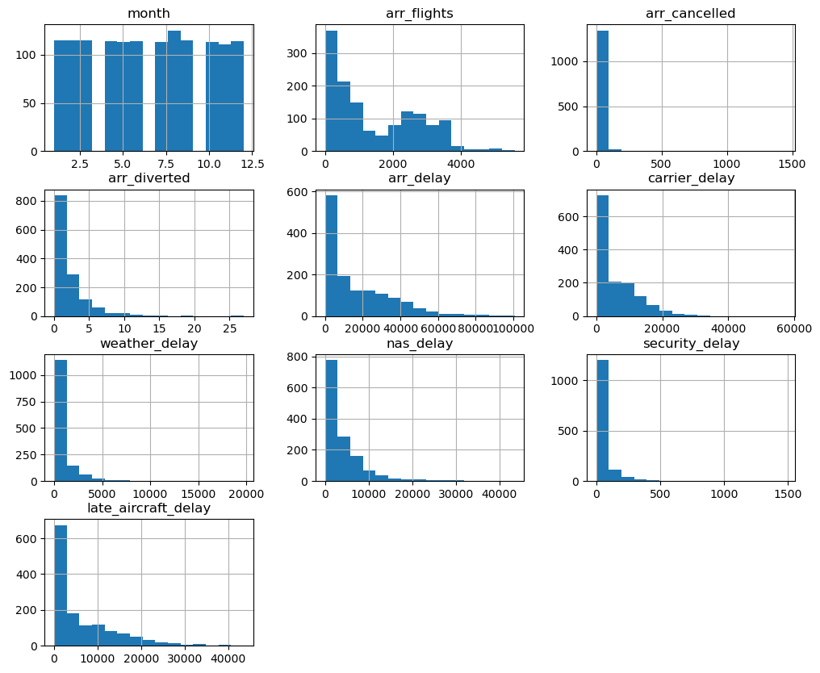

```python
flights.hist(bins=15, figsize=(12,10))
```

#### Inital Skewness

Due to almost all variables being skewed to the right, each variable was measured for a quantitative skew amount. The formula standardizes the third power of deviations from the mean, capturing the asymmetry of the distribution. Skew values above 0.75 are considered to be highly skewed. Skew values greater than 0 show right skew and skew values less than 0 show left skew. A skew value of 0 implies a normal distribution.

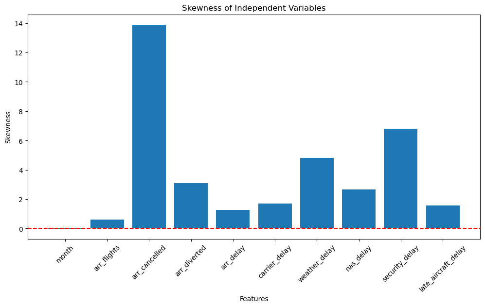

```
Highly skewed variables:
arr_cancelled          13.901677
arr_diverted            3.103698
arr_delay               1.279688
carrier_delay           1.704594
weather_delay           4.831526
nas_delay               2.668292
security_delay          6.804744
late_aircraft_delay     1.570751
dtype: float64
```

```python
from scipy.stats import skew

flights_num = flights.select_dtypes(include=[np.number])
skew_values = flights_num.apply(skew)

# Visualize skewness
myblue = '#1f77b4'
plt.figure(figsize=(12, 6))
plt.bar(flights_num.columns, skew_values, color=myblue)
plt.axhline(0, color='red', linestyle='--')
plt.title('Skewness of Independent Variables')
plt.xlabel('Features')
plt.ylabel('Skewness')
plt.xticks(rotation=45)
plt.show()

# Print highly skewed variables
print("Highly skewed variables:")
print(skew_values[abs(skew_values) > 0.75])
```

#### Data Transformation

Since the data is skewed to the right, a logrithmic transformation was applied to each of the highly skewed variables. This improved the skewness of several variables, but a few variables exhibited a left skew after transformation. The absolute value of the skew values was still lower, so the transformation was kept for these variables.

```python
highly_skewed = [
    'arr_cancelled', 'arr_diverted', 'arr_delay', 'carrier_delay',
    'weather_delay', 'nas_delay', 'security_delay', 'late_aircraft_delay'
]

for col in highly_skewed:
    flights[col + '_log'] = np.log(flights[col] + 1)
```

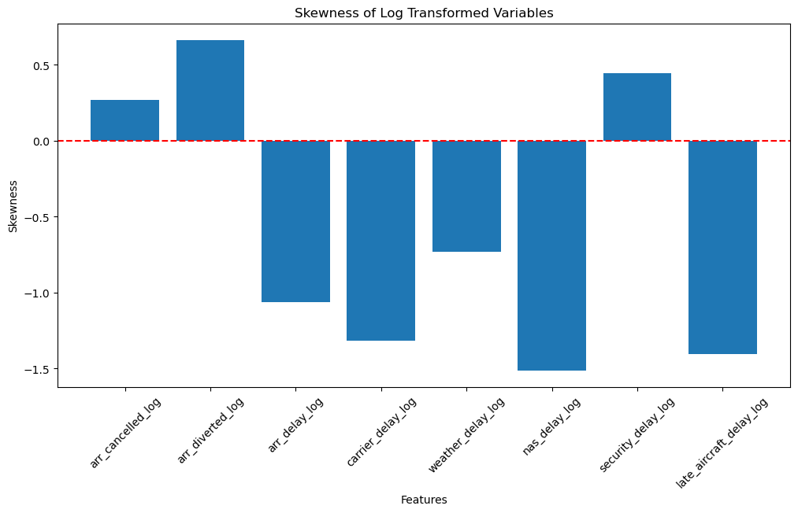

```
Highly Skewed Varaibles After Log transformation:
arr_delay_log             -1.061868
carrier_delay_log         -1.314086
nas_delay_log             -1.511507
late_aircraft_delay_log   -1.403961
dtype: float64
```

```python
from scipy.stats import skew

flights_num_log = flights[[col + '_log' for col in highly_skewed]]
skew_values = flights_num_log.apply(skew)

# Visualize skewness
import matplotlib.pyplot as plt
plt.figure(figsize=(12, 6))
plt.bar(flights_num_log.columns, skew_values, color=myblue)
plt.axhline(0, color='red', linestyle='--')
plt.title('Skewness of Log Transformed Variables')
plt.xlabel('Features')
plt.ylabel('Skewness')
plt.xticks(rotation=45)
plt.show()

# Print highly skewed variables after transformation
print("Highly Skewed Varaibles After Log transformation:")
print(skew_values[abs(skew_values) > 0.75])
```

Below we can see the new distributions and summary statistics of each variable after the log transformation.

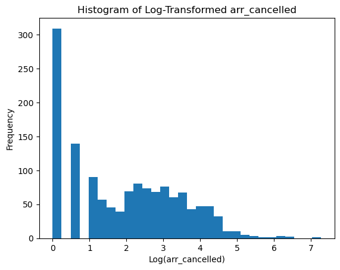

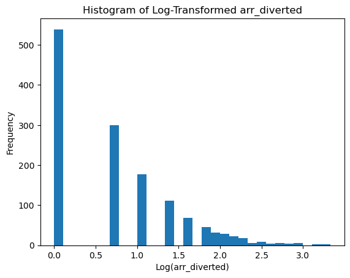

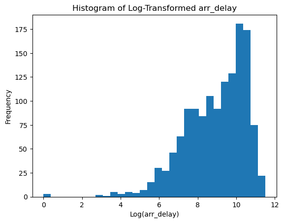

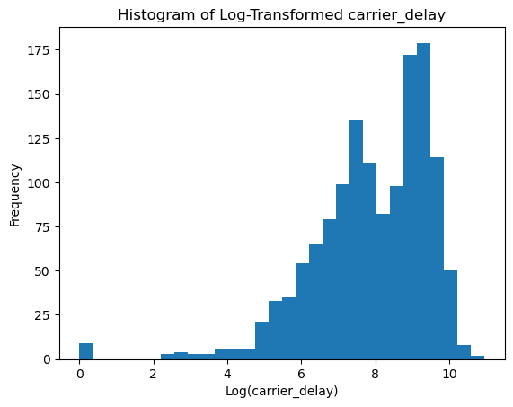

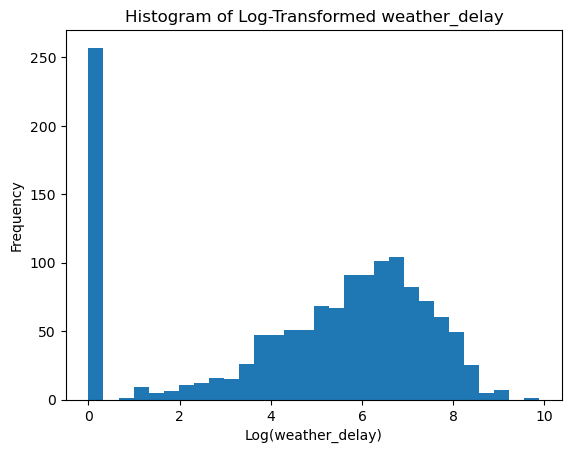

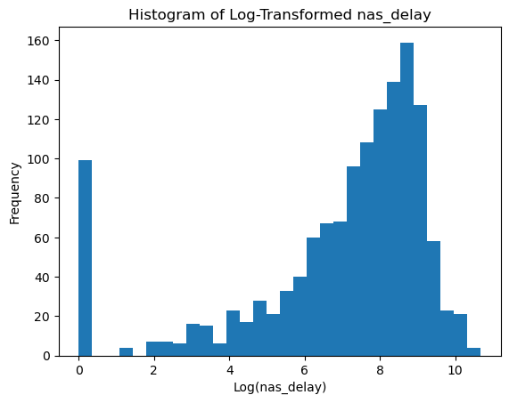

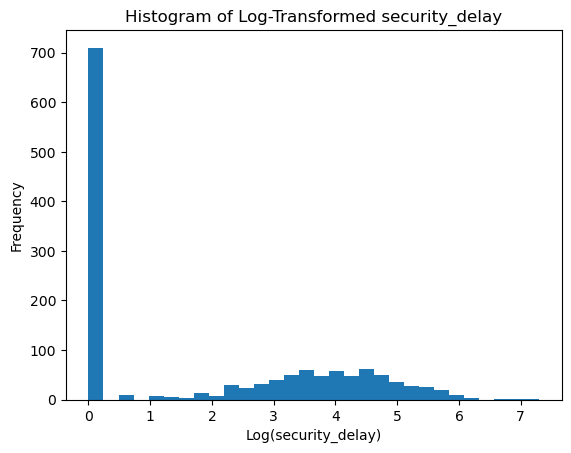

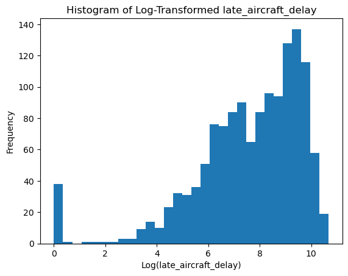

```python
for col in highly_skewed:
    plt.figure()
    plt.hist(flights[col + '_log'], bins=30, color=myblue)
    plt.title(f'Histogram of Log-Transformed {col}')
    plt.xlabel(f'Log({col})')
    plt.ylabel('Frequency')
    plt.show()
```

```python
flights.drop(columns=highly_skewed, inplace=True)
flights.describe()
```

|  | month | arr_flights | arr_cancelled_log | arr_diverted_log | arr_delay_log | carrier_delay_log | weather_delay_log | nas_delay_log | security_delay_log | late_aircraft_delay_log |
| --- | --- | --- | --- | --- | --- | --- | --- | --- | --- | --- |
| count | 1377.000000 | 1377.000000 | 1377.000000 | 1377.000000 | 1377.000000 | 1377.000000 | 1377.000000 | 1377.000000 | 1377.000000 | 1377.000000 |
| mean | 6.492375 | 1465.889535 | 1.931716 | 0.767566 | 8.926082 | 7.899052 | 4.761994 | 6.927248 | 1.871320 | 7.585189 |
| std | 3.443921 | 1270.517160 | 1.506878 | 0.760829 | 1.596828 | 1.594576 | 2.694467 | 2.532001 | 2.090180 | 2.133269 |
| min | 1.000000 | 2.000000 | 0.000000 | 0.000000 | 0.000000 | 0.000000 | 0.000000 | 0.000000 | 0.000000 | 0.000000 |
| 25% | 3.000000 | 290.000000 | 0.693147 | 0.000000 | 7.837949 | 7.007601 | 3.465736 | 6.175867 | 0.000000 | 6.478510 |
| 50% | 7.000000 | 980.000000 | 1.945910 | 0.693147 | 9.267760 | 8.096208 | 5.587249 | 7.716015 | 0.000000 | 8.016648 |
| 75% | 9.000000 | 2581.000000 | 3.135494 | 1.386294 | 10.227381 | 9.138307 | 6.775366 | 8.626406 | 3.891820 | 9.227492 |
| max | 12.000000 | 5571.000000 | 7.280008 | 3.332205 | 11.519931 | 10.956684 | 9.889084 | 10.679711 | 7.301822 | 10.682078 |

#### Correlation

The correlation matrix below reveals some strong correlations between variables. This raises flags that multicollinearity may be an issue. Multicollinearity occurs when two or more independent variables in a regression model are highly correlated, meaning they provide redundant information about the dependent variable. This can make it difficult to determine the individual effect of each predictor and lead to large fluctuations in coefficient estimations, large variances, lower statistical significance, and reduced interpretability.

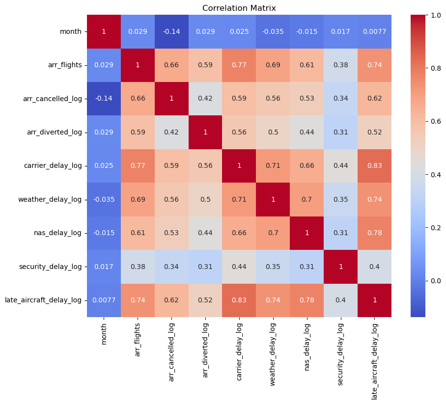

```python
flight_vif = flights.drop(['arr_delay_log'], axis=1)
correlation_matrix = flight_vif.corr()

plt.figure(figsize=(10, 8))
sns.heatmap(correlation_matrix, annot=True, cmap='coolwarm')
plt.title('Correlation Matrix')
plt.show()
```

#### VIF

To check if multicollinearity is an imminent issue, the variance inflaction factor (VIF) was used. This measures the extent of multicollinearity in regression models. It quantifies how much the variance of a regression coefficient is inflated due to correlation with other predictors.

- VIF > 10: Signifies high multicollinearity, which should be dealt with accordingly before modeling.
- VIF > 5: Signifies moderate multicollinearity, where it can affect results and may need to be dealt with.
- VIF < 5: Multicollinearity may be present, but it is unlikely to strongly affect modeling.
- VIF = 1: No multicollinearity is present.

In this case, all VIF values are less than 5, so no more adjustments were done.

```python
flight_numeric = flight_vif.apply(pd.to_numeric)

# Add a constant column for the intercept
vif = sm.add_constant(flight_numeric)

# Calculate VIF for each predictor variable (skipping the constant column)
vif_data = pd.DataFrame()
vif_data["Feature"] = vif.columns[1:]  # Skip the constant column
vif_data["VIF"] = [variance_inflation_factor(vif.values, i)
                   for i in range(1, vif.shape[1])]  # Start from index 1

print(vif_data)
```

```
                   Feature       VIF
0                    month  1.054719
1              arr_flights  3.415203
2        arr_cancelled_log  2.041160
3         arr_diverted_log  1.614598
4        carrier_delay_log  4.227227
5        weather_delay_log  2.747367
6            nas_delay_log  2.783191
7       security_delay_log  1.267284
8  late_aircraft_delay_log  4.960604
```

## Non-supervised learning

#### Three unsupervised models were evaluated:

- Gaussian Mixture Model
- PCA
- t-SNE

The gaussian mixture model is a probabilitic model that is used for clustering and density estimation. It is similar to the KMeans model because it uses a certain number of components. Below, we use AIC and BIC to help decide the ideal number of components. The reason we chose the gaussian mixture model over the Kmeans model is because not only did we get better results using GMM, but our clusters are not perfectly separated. GMM handles these types of clusters better and has more flexible cluster shapes compared to KMeans. However, we did have issues because our data has a large number of components which can risk overfitting the data.

```python
from sklearn.mixture import GaussianMixture
from sklearn.preprocessing import StandardScaler

scaler = StandardScaler()
X = flights.drop(['arr_delay_log'], axis=1)
X_scaled = scaler.fit_transform(X)


gmm = GaussianMixture(n_components=3, n_init=10)
gmm.fit(X_scaled)

# Predict the cluster labels
labels = gmm.predict(X_scaled)

# Add the labels as a new column to the dataframe
X['Cluster'] = labels
```

```python
print("Cluster Weights (weights of the Gaussian components):")
print(gmm.weights_)
```

```
Cluster Weights (weights of the Gaussian components):
[0.37405873 0.4110131  0.21492816]
```

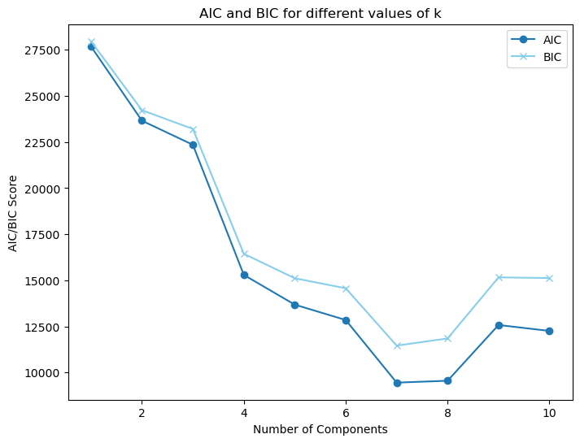

```python
# Try multiple values of n_components and compute AIC and BIC
n_components_range = range(1, 11)  # Try 1 to 10 components
aic_scores = []
bic_scores = []

for n_components in n_components_range:
    gmm = GaussianMixture(n_components=n_components, random_state=42)
    gmm.fit(X_scaled)
    aic_scores.append(gmm.aic(X_scaled))
    bic_scores.append(gmm.bic(X_scaled))

# Plot AIC and BIC to visualize the optimal number of components
plt.figure(figsize=(8, 6))
plt.plot(n_components_range, aic_scores, label='AIC', color=myblue, marker='o')
plt.plot(n_components_range, bic_scores, label='BIC', color='skyblue', marker='x')
plt.xlabel('Number of Components')
plt.ylabel('AIC/BIC Score')
plt.title('AIC and BIC for different values of k')
plt.legend()
plt.show()
```

### Model 2: PCA 2D reduction

#### This can help visualize the clusters made in the gaussian mixture

PCA reduction can help reduce the dimensionality of our data while also preserving as much information as possible. Since we are using a larger dataset, we chose PCA of t-SNE because we are more focused on potentially using the reduced feature for further modeling. We reduce the dataset to 2 dimensions in order to make the visualizations easier and preserve maximum variance.

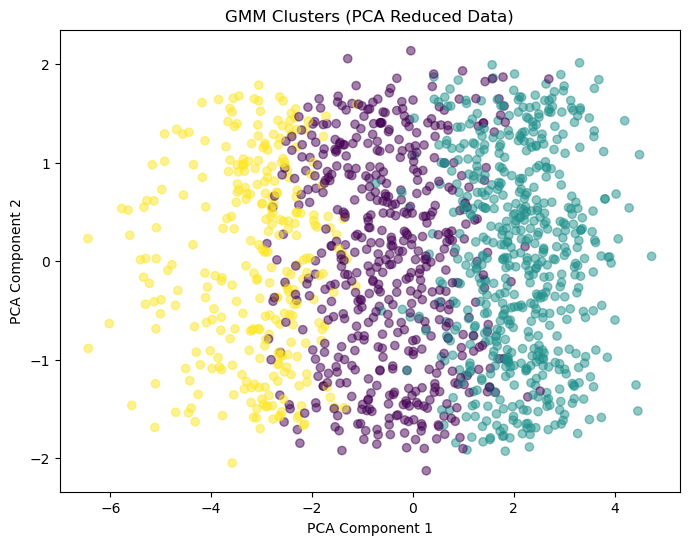

```python
from sklearn.decomposition import PCA

pca = PCA(n_components=2)
df_pca = pca.fit_transform(X_scaled)

# Plot the 2D PCA-reduced data with clusters
plt.figure(figsize=(8, 6))
plt.scatter(df_pca[:, 0], df_pca[:, 1], c=labels, cmap='viridis', alpha=0.5)
plt.title('GMM Clusters (PCA Reduced Data)')
plt.xlabel('PCA Component 1')
plt.ylabel('PCA Component 2')
plt.show()
```

Since the clusters are not great, we can also try t-SNE to see if that helps in the visualization.

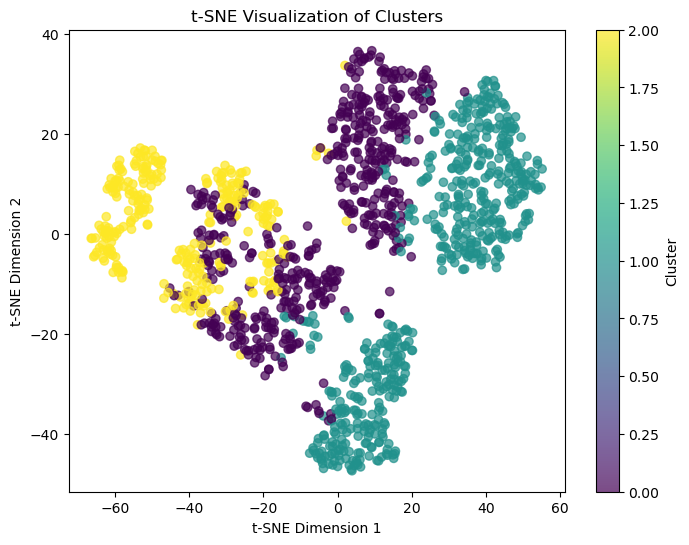

```python
from sklearn.manifold import TSNE

tsne = TSNE(n_components=2, perplexity=30, learning_rate=200, random_state=42)
X_tsne = tsne.fit_transform(X_scaled)

# Plot the t-SNE result
plt.figure(figsize=(8, 6))
plt.scatter(X_tsne[:, 0], X_tsne[:, 1], c=labels, cmap='viridis', alpha=0.7)
plt.title('t-SNE Visualization of Clusters')
plt.xlabel('t-SNE Dimension 1')
plt.ylabel('t-SNE Dimension 2')
plt.colorbar(label='Cluster')
plt.show()
```

We will not be using the findings in the non-supervised learning because there are no clear findings that would aid our supervised models. The clustering is not as clear as we would hope for it to be and the dimension reductions are not as clear either. However, our supervised learning models work well and represent our data well. We did not include it in the project but we did test the PCA dataframe in our models and it resulted in worse results, so we decided to not include the clustering or dimension reduction.

## Supervised Learning Models

#### Five supervised learning models were evaulted:

- Linear Regression
- Decision Tree Regression
- Random Forest Regression
- Support Vector Regression (SVR)
- Extreme Gradiant Boosting Regressor (XGBRegressor)

#### Each model is evaulated on 4 regression metrics:

- Mean Squared Error (MSE): Measures the average squared difference between predicted and actual values. It penalizes larger errors more heavily, making it sensitive to outliers.
- Root Mean Square Error (RMSE): The square root of MSE, providing error in the same unit as the dependent variable. Easier to interpret than MSE but still penalizes larger errors.
- Mean Absolute Error (MAE): Measures the average absolute difference between predicted and actual values. It treats all errors equally, making it less sensitive to outliers.
- R² Score: Represents the proportion of variance in the dependent variable explained by the model. It ranges from 0 (no explanatory power) to 1 (perfect fit).

#### Train/Test Split

- To start, the data had to be split into testing and training sets. A general balance of 20% of the data was assigned to the test set.
- The target variable, "arr_delay_log" which represents the log transformed value of total delay time was assigned to y.
- All other variables serve as predictive variables and were assigned to X.

```python
from sklearn.model_selection import train_test_split
from sklearn.metrics import mean_squared_error, mean_absolute_error, r2_score

X = flights.drop(['arr_delay_log'], axis=1)
y = flights['arr_delay_log']
X_train, X_test, y_train, y_test = train_test_split(X, y, test_size = 0.2, random_state = 42)
```

### Model 1: Linear Regression

Linear regression is a statistical and machine learning method used to model the relationship between a dependent variable (target) and one or more independent variables (predictors). It assumes a linear relationship and minimizes the sum of squared residuals to find the best-fit line. This is an ideal model for measuring the linear relationship of the data.

#### Methods:

- Equation: Linear regression models the target variable y = mx+b, where y is the target and there can be multiple x and m values in the equation.
- Optimization: The model finds the line (or hyperplane) that minimizes the sum of squared errors (differences between predicted and actual values).
- Prediction: For new inputs, predictions are calculated using the fitted linear equation.

#### Benefits:

- Simplicity: Easy to understand, implement, and interpret.
- Efficient Baseline: Provides a straightforward starting point for modeling and evaluating relationships in -data.
- Interpretability: Coefficients explain how changes in predictors affect the target.
- Speed: Computationally efficient, even for large datasets.

#### Limitations:

- Assumes linearity, which may not hold for all datasets.
- Sensitive to outliers and multicollinearity.
- Requires normally distributed residuals and constant variance.

#### Results:

- Mean Squared Error (MSE): 0.075 is very low, suggesting that the average squared difference between predicted and actual log-transformed values is small.
- Root Mean Squared Error (RMSE): 0.274 represents the average prediction error in the same scale as the log-transformed data. It’s low, indicating good model accuracy.
- Mean Absolute Error (MAE): 0.155 indicates the average absolute difference between predicted and actual log-transformed values, which is very low.
- R² Score: 0.966 means that 96.6% of the variance in the log-transformed target variable is explained by the model. This is an excellent score, indicating a strong fit.

```python
from sklearn.model_selection import cross_val_score
from sklearn.linear_model import LinearRegression

linreg = LinearRegression()
linreg.fit(X_train, y_train)

y_pred_linreg = linreg.predict(X_test)

mse_linreg = mean_squared_error(y_test, y_pred_linreg)
rmse_linreg = np.sqrt(mean_squared_error(y_test, y_pred_linreg))
mae_linreg = mean_absolute_error(y_test, y_pred_linreg)
r2_linreg = r2_score(y_test, y_pred_linreg)
cv_mae_linreg = cross_val_score(linreg, X, y, scoring='neg_mean_absolute_error', cv=5)

print("Mean Squared Error:", mse_linreg)
print("Root Mean Squared Error:", rmse_linreg)
print("Mean Absolute Error:", mae_linreg)
print("R² Score:", r2_linreg)
```

```
Mean Squared Error: 0.07503662655726206
Root Mean Squared Error: 0.273928141229159
Mean Absolute Error: 0.1551178932792618
R² Score: 0.9656363872108431
```

### Model 2: Decision Tree

Decision Tree Regression is a supervised learning algorithm that predicts a target variable by recursively splitting the data into subsets based on the most significant predictor features. The result is a tree-like structure where each internal node represents a decision (a feature and threshold), branches represent possible outcomes, and leaf nodes represent predicted values.

#### Benefits:

- Nonlinear Relationships: Captures complex, nonlinear patterns in the data without requiring feature transformations.
- Interpretability: The decision-making process is easy to visualize and understand.
- Feature Importance: Naturally identifies the most influential features.
- Versatility: Handles both numerical and categorical data effectively.

#### Limitations:

- Prone to overfitting unless properly regularized (e.g., limiting depth or number of samples per leaf).
- Sensitive to small changes in data (high variance).
- May not generalize well for small datasets.

#### Initial Model Results:

- Mean Squared Error (MSE): 0.131: Higher than before, meaning the average squared error has increased. However, it is still relatively low, indicating good accuracy on the log-transformed scale.
- Root Mean Squared Error (RMSE): 0.362: Provides a more interpretable measure of average error, as it is on the same scale as the log-transformed data. This value is slightly higher than the previous 0.274, indicating more prediction error.
- Mean Absolute Error (MAE): 0.238: The average absolute prediction error has increased but remains acceptable for many applications, depending on the context.
- R² Score: 0.940: A drop from 0.966, but still a strong score. This means that 94.0% of the variance in the log-transformed target variable is explained by the model.

```python
from sklearn.tree import DecisionTreeRegressor
from sklearn.metrics import mean_squared_error, r2_score

# Train Decision Tree Regressor
dt_model = DecisionTreeRegressor(max_depth=5, random_state=42)  # Limit depth to prevent overfitting
dt_model.fit(X_train, y_train)

# Evaluate
y_pred_dt = dt_model.predict(X_test)

mse_dt = mean_squared_error(y_test, y_pred_dt)
rmse_dt = np.sqrt(mean_squared_error(y_test, y_pred_dt))
mae_dt = mean_absolute_error(y_test, y_pred_dt)
r2_dt = r2_score(y_test, y_pred_dt)

print("Mean Squared Error:", mse_dt)
print("Root Mean Squared Error:", rmse_dt)
print("Mean Absolute Error:", mae_dt)
print("R² Score:", r2_dt)
```

```
Mean Squared Error: 0.1313210382196097
Root Mean Squared Error: 0.36238244744966563
Mean Absolute Error: 0.2375206752900513
R² Score: 0.939860498592577
```

#### Hyperparameter Tuning

The original decision tree model results are relatively good already, but we could possibly improve the results. Parameters are tuned based on Negative Mean Absolute Error, since the dataset does display skew and outliers and this metric is the least sensitive to outliers.

#### Hyperparameters:

- max_depth: The maximum depth of the decision tree. A higher value allows the model to learn more complex patterns, but it risks overfitting.
- max_features: The number of features to consider when looking for the best split. Setting it to sqrt means using the square root of the total features, which helps balance performance and computation.
- min_samples_leaf: The minimum number of samples required to be in a leaf node. A value of 1 allows the tree to grow deeply, potentially capturing noise.
- min_samples_split: The minimum number of samples required to split a node. A value of 2 ensures that every split has at least two samples, promoting growth and granularity.

```python
# Define parameter grid
param_grid = {
    'max_depth': [5, 10, 20, None],
    'min_samples_split': [2, 5, 10],
    'min_samples_leaf': [1, 2, 4],
    'max_features': ['auto', 'sqrt', 'log2']
}

# Initialize Decision Tree Regressor
dt = DecisionTreeRegressor(random_state=42)

# Perform Grid Search
grid_search_dt = GridSearchCV(estimator=dt, param_grid=param_grid, cv=5, scoring='neg_mean_absolute_error', verbose=0, n_jobs=-1)
grid_search_dt.fit(X_train, y_train)
best_params_rf = grid_search_dt.best_params_

print("\nBest Parameters:")
for param, value in best_params_rf.items():
    print(f"{param}: {value}")
```

```
Best Parameters:
max_depth: 20
max_features: sqrt
min_samples_leaf: 1
min_samples_split: 2
```

#### Model Results after Tuning

The hyperparameter tuning has significantly improved the decision tree model's performance, as evident from the metrics before and after tuning:

```python
# Train Decision Tree Regressor
dt_model_tuned = DecisionTreeRegressor(max_depth=20, max_features = 'sqrt', min_samples_leaf = 1, min_samples_split = 2, random_state=42)  # Limit depth to prevent overfitting
dt_model_tuned.fit(X_train, y_train)

# Evaluate
y_pred_dt_tuned = dt_model_tuned.predict(X_test)

mse_dt_tuned = mean_squared_error(y_test, y_pred_dt_tuned)
rmse_dt_tuned = np.sqrt(mean_squared_error(y_test, y_pred_dt_tuned))
mae_dt_tuned = mean_absolute_error(y_test, y_pred_dt_tuned)
r2_dt_tuned = r2_score(y_test, y_pred_dt_tuned)

print("Mean Squared Error:", mse_dt_tuned)
print("Root Mean Squared Error:", rmse_dt_tuned)
print("Mean Absolute Error:", mae_dt_tuned)
print("R² Score:", r2_dt_tuned)
```

```
Mean Squared Error: 0.08206938474161476
Root Mean Squared Error: 0.286477546662238
Mean Absolute Error: 0.20561700539244923
R² Score: 0.9624156803350824
```

#### Feature Importances

Dominant Features:

- carrier_delay_log: With an importance of 0.76, this feature overwhelmingly drives the model's predictions.
- late_aircraft_delay_log: At 0.14, it is the second most important feature but is significantly less impactful than carrier_delay_log.

Moderately Important:

- nas_delay_log: Importance 0.065, contributes meaningfully to the model but far less than the top two features.

Low Importance:

- The remaining features, such as arr_flights, security_delay_log, and arr_cancelled_log, have importance values below 0.01, indicating minimal impact on predictions.

Negligible Contribution:

- arr_diverted_log (0.0007) and weather_delay_log (0.0044) barely influence the model, and their inclusion might not be critical.

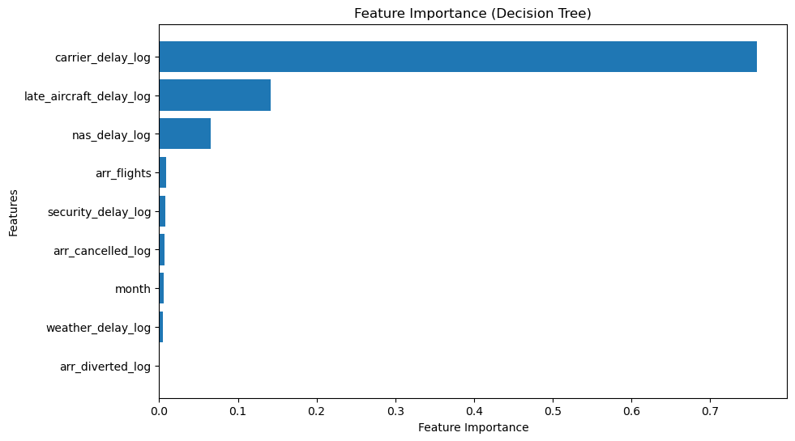

|  | Feature | Importance |
| --- | --- | --- |
| 4 | carrier_delay_log | 0.759927 |
| 8 | late_aircraft_delay_log | 0.141241 |
| 6 | nas_delay_log | 0.065073 |
| 1 | arr_flights | 0.008996 |
| 7 | security_delay_log | 0.007630 |
| 2 | arr_cancelled_log | 0.006401 |
| 0 | month | 0.005649 |
| 5 | weather_delay_log | 0.004427 |
| 3 | arr_diverted_log | 0.000656 |

```python
importances = dt_model_tuned.feature_importances_
features = X.columns
feature_importance_df = pd.DataFrame({
    'Feature': features,
    'Importance': importances
})

# Sort by importance (descending order)
feature_importance_df = feature_importance_df.sort_values(by='Importance', ascending=False)

# Plot the horizontal bar chart
plt.figure(figsize=(10, 6))
plt.barh(feature_importance_df['Feature'], feature_importance_df['Importance'], color=myblue)
plt.xlabel("Feature Importance")
plt.ylabel("Features")
plt.title("Feature Importance (Decision Tree)")
plt.gca().invert_yaxis()  # Invert y-axis for descending order
plt.show()

feature_importance_df
```

### Model 3: Random Forest

Random Forest is a powerful and versatile machine learning algorithm that combines the predictions of multiple decision trees to improve accuracy and reduce overfitting. It belongs to the family of ensemble methods, where multiple models work together to produce a more robust result.

#### Methods:

- Bootstrap Sampling: The algorithm creates multiple subsets of the training data by sampling with replacement (bootstrap).
- Decision Tree Training: For each subset, a decision tree is trained independently, and at each split, only a random subset of features is considered to reduce correlation among trees.
- Aggregation: The average of predictions from all trees is taken as the final output.

#### Strengths:

- Handles Nonlinear Relationships: Effectively captures complex patterns in the data.
- Reduces Overfitting: The ensemble of trees generalizes better than individual decision trees.
- Feature Importance: Provides a ranking of features based on their contribution to the model's predictions.
- Versatility: Works well with both numerical and categorical data, as well as datasets with missing values.
- Robustness: Less sensitive to noise or small changes in the dataset compared to single decision trees.

#### Limitations:

- Computationally intensive for large datasets.
- May require hyperparameter tuning for optimal performance.

#### Results:

- Mean Squared Error (MSE): 0.025: Extremely low, meaning the average squared prediction error is minimal.
- Root Mean Squared Error (RMSE): 0.159: Provides an interpretable error measure on the same scale as the target variable (log-transformed), indicating very accurate predictions.
- Mean Absolute Error (MAE): 0.073: The average absolute prediction error is remarkably low, suggesting high precision in the predictions.
- R² Score: 0.988: Nearly perfect, indicating that 98.8% of the variance in the target variable is explained by the model.

```python
from sklearn.ensemble import RandomForestRegressor

# Train Random Forest Regressor
rf_model = RandomForestRegressor(n_estimators=100, random_state=42)
rf_model.fit(X_train, y_train)

# Evaluate1
y_pred_rf = rf_model.predict(X_test)

mse_rf = mean_squared_error(y_test, y_pred_rf)
rmse_rf = np.sqrt(mean_squared_error(y_test, y_pred_rf))
mae_rf = mean_absolute_error(y_test, y_pred_rf)
r2_rf = r2_score(y_test, y_pred_rf)

print("Mean Squared Error:", mse_rf)
print("Root Mean Squared Error:", rmse_rf)
print("Mean Absolute Error:", mae_rf)
print("R² Score:", r2_rf)
```

```
Mean Squared Error: 0.024977127166059883
Root Mean Squared Error: 0.15804153620507452
Mean Absolute Error: 0.07173602899473949
R² Score: 0.9885615283375643
```

#### Hyperparameter Tuning

Random forest uses many of the same parameters as decision trees, due to their relation. There is one additional hyperparameter that was tuned:

- n_estimators: The number of trees used in the random forest. Higher values can improve the model's stability and generalization by reducing variance (overfitting) through averaging but can also increase computational time without significant performance gains.

```python
from sklearn.ensemble import RandomForestRegressor
from sklearn.model_selection import GridSearchCV

# Define the parameter grid
param_grid = {
    'n_estimators': [100, 200, 500],
    'max_depth': [None, 10, 20],
    'min_samples_split': [2, 5, 10],
    'min_samples_leaf': [1, 2, 4],
    'max_features': ['auto', 'sqrt']
}

grid_search_rf = GridSearchCV(RandomForestRegressor(), param_grid, cv=5, scoring='neg_mean_absolute_error', verbose=0)
grid_search_rf.fit(X_train, y_train)
best_params_rf = grid_search_rf.best_params_

print("\nBest Parameters:")
for param, value in best_params_rf.items():
    print(f"{param}: {value}")
```

```
Best Parameters:
max_depth: None
max_features: sqrt
min_samples_leaf: 1
min_samples_split: 2
n_estimators: 500
```

#### Model results after tuning

This Random Forest model achieves very high accuracy and robustness. The marginal increase in MAE is negligible given the overall gains in error reduction and explanatory power. It’s likely close to the optimal performance for this dataset.

- Overall Improvement: The reduction in MSE and RMSE suggests that the model's predictions are more precise.
- Tradeoff in MAE: A slight increase in MAE may indicate the model's adjustments favored minimizing larger residuals at the cost of slightly larger average absolute errors.
- R² Close to Perfection: A R² of 0.992 signifies near-perfect model performance, capturing almost all variance in the data.

```python
rf_model_tuned = RandomForestRegressor(max_depth = 20, max_features = 'sqrt', min_samples_leaf = 1, min_samples_split = 2, n_estimators = 500, random_state=42)
rf_model_tuned.fit(X_train, y_train)

# Evaluate1
y_pred_rf_tuned = rf_model_tuned.predict(X_test)

mse_rf_tuned = mean_squared_error(y_test, y_pred_rf_tuned)
rmse_rf_tuned = np.sqrt(mean_squared_error(y_test, y_pred_rf_tuned))
mae_rf_tuned = mean_absolute_error(y_test, y_pred_rf_tuned)
r2_rf_tuned = r2_score(y_test, y_pred_rf_tuned)

print("Mean Squared Error:", mse_rf_tuned)
print("Root Mean Squared Error:", rmse_rf_tuned)
print("Mean Absolute Error:", mae_rf_tuned)
print("R² Score:", r2_rf_tuned)
```

```
Mean Squared Error: 0.016638752815207224
Root Mean Squared Error: 0.12899128968735535
Mean Absolute Error: 0.0738532988254086
R² Score: 0.992380152396644
```

#### Feature Importances

Top Features:

- late_aircraft_delay_log (0.321) and carrier_delay_log (0.307) dominate the model, accounting for over 60% of the importance combined. These features are critical to the model's predictive performance. This is also reflected in the feature importance of the decision tree model.
- arr_flights (0.178) is also influential, indicating it plays a significant role in the predictions.

Moderately Important:

- nas_delay_log (0.119) contributes meaningfully but is less impactful compared to the top three features.

Low Importance:

- Features like weather_delay_log (0.039) and arr_cancelled_log (0.022) have limited influence on the predictions.

Negligible Features:

- month (0.005), arr_diverted_log (0.005), and security_delay_log (0.003) have minimal impact, suggesting they might not be critical for this model.

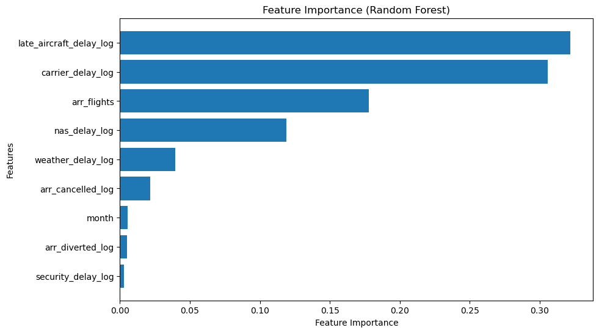

|  | Feature | Importance |
| --- | --- | --- |
| 8 | late_aircraft_delay_log | 0.322042 |
| 4 | carrier_delay_log | 0.305711 |
| 1 | arr_flights | 0.178050 |
| 6 | nas_delay_log | 0.119112 |
| 5 | weather_delay_log | 0.039597 |
| 2 | arr_cancelled_log | 0.021813 |
| 0 | month | 0.005424 |
| 3 | arr_diverted_log | 0.005251 |
| 7 | security_delay_log | 0.002999 |

```python
importances = rf_model_tuned.feature_importances_
features = X.columns
feature_importance_df = pd.DataFrame({
    'Feature': features,
    'Importance': importances
})

# Sort by importance (descending order)
feature_importance_df = feature_importance_df.sort_values(by='Importance', ascending=False)

# Plot the horizontal bar chart
plt.figure(figsize=(10, 6))
plt.barh(feature_importance_df['Feature'], feature_importance_df['Importance'], color=myblue)
plt.xlabel("Feature Importance")
plt.ylabel("Features")
plt.title("Feature Importance (Random Forest)")
plt.gca().invert_yaxis()  # Invert y-axis for descending order
plt.show()

feature_importance_df
```

### Model 4: Support Vector Regression (SVR)

Support Vector Regression (SVR) is a machine learning algorithm that uses the principles of Support Vector Machines (SVM) to perform regression tasks. It is particularly effective for capturing complex relationships and handling outliers by focusing on the most important data points.

#### Methods:

- Margin of Tolerance: SVR tries to fit a line (or hyperplane) that predicts the target variable while allowing a margin of tolerance (ϵ) for error.
- Support Vectors: Only the data points near the margin boundaries (support vectors) influence the model, reducing the impact of outliers.
- Kernels for Nonlinear Relationships: By using kernels (e.g., linear, polynomial, RBF), SVR can model nonlinear relationships between variables.

#### Strengths:

- Handles Nonlinear Data: Kernels allow SVR to capture complex patterns effectively.
- Robustness to Outliers: By ignoring errors outside the margin (ϵ), it minimizes the impact of outliers.
- Flexibility: Works well for both small and large datasets with proper hyperparameter tuning.
- Generalization: Focus on support vectors reduces the risk of overfitting.

#### Limitations:

- Computationally Intensive: Can be slow for large datasets.
- Sensitive to Hyperparameters: Performance depends heavily on the choice of kernel, C (regularization), and ϵ (margin).
- Less Interpretable: Unlike linear regression, SVR coefficients are harder to interpret.

#### Results:

- Mean Squared Error (MSE): 2.191: Very high, indicating large discrepancies between predicted and actual values.
- Root Mean Squared Error (RMSE): 1.480: Reflects significant average error in the predictions, on the same scale as the target variable.
- Mean Absolute Error (MAE): 1.236: The average absolute difference between predictions and actual values is substantial, suggesting poor accuracy.
- R² Score: −0.0036: A negative R² indicates the model performs worse than a simple horizontal line at the mean value of the target variable. Essentially, the model fails to capture any meaningful relationship between predictors and the target.

```python
from sklearn.svm import SVR
from sklearn.preprocessing import StandardScaler

# Scale the features
scaler = StandardScaler()
X_train_scaled = scaler.fit_transform(X_train)
X_test_scaled = scaler.transform(X_test)

# Train SVR
svr_model = SVR(kernel='rbf', C=1.0, epsilon=0.1)
svr_model.fit(X_train_scaled, y_train)

# Evaluate
y_pred_svr = svr_model.predict(X_test)

mse_svr = mean_squared_error(y_test, y_pred_svr)
rmse_svr = np.sqrt(mean_squared_error(y_test, y_pred_svr))
mae_svr = mean_absolute_error(y_test, y_pred_svr)
r2_svr = r2_score(y_test, y_pred_svr)

print("Mean Squared Error:", mse_svr)
print("Root Mean Squared Error:", rmse_svr)
print("Mean Absolute Error:", mae_svr)
print("R² Score:", r2_svr)
```

```
Mean Squared Error: 2.191428727001718
Root Mean Squared Error: 1.48034750210946
Mean Absolute Error: 1.2358665939645912
R² Score: -0.003582006345324462
```

#### Hyperparameter Tuning

- C: This is the regularization parameter that controls the trade-off between achieving a low error on the training set and maintaining a smooth decision boundary.
- epsilon: This defines the width of the margin of tolerance where predictions are not penalized for being different from the true values. Within this margin, deviations are considered acceptable and do not contribute to the loss function.
- kernel: A mathematical function that transforms the input data into a higher-dimensional space to make it easier to separate or model relationships that are not linearly separable in the original space.
  - The rbf (Radial Basis Function) kernel is a nonlinear kernel that maps input features into a higher-dimensional space to capture complex relationships.

```python
from sklearn.model_selection import GridSearchCV
from sklearn.svm import SVR

param_grid = {
    'C': [0.1, 1, 10, 100],
    'epsilon': [0.01, 0.1, 1],
    'kernel': ['linear', 'poly', 'rbf']
}

grid_search_svr = GridSearchCV(SVR(), param_grid, cv=5, scoring='neg_mean_absolute_error', verbose=0)
grid_search_svr.fit(X_train_scaled, y_train)
best_params_svr = grid_search_svr.best_params_

print("\nBest Parameters:")
for param, value in best_params_svr.items():
    print(f"{param}: {value}")
```

```
Best Parameters:
C: 100
epsilon: 0.01
kernel: rbf
```

#### Model results after tuning

- Mean Squared Error (MSE): 0.0026: Extremely low, showing minimal average squared error. This indicates a significant reduction in error compared to the initial results.
- Root Mean Squared Error (RMSE): 0.0512: Very small, representing an excellent fit. This is the average prediction error on the same scale as the target variable.
- Mean Absolute Error (MAE): 0.0263: Indicates the average absolute error is minimal, suggesting high precision in predictions.
- R² Score: 0.9988: Near-perfect R² score, indicating that 99.88% of the variance in the target variable is explained by the model.

#### Observations:

- Drastic Improvement: Compared to the initial metrics, the tuned model has dramatically reduced all error measures and increased the R² score.
- Precision and Robustness: The very low RMSE and MAE suggest the model is highly precise and makes consistent predictions.
- Effective Tuning: The hyperparameter adjustments (e.g., C, epsilon, and kernel) successfully optimized the model to handle the data's complexity.

```python
# Train SVR
svr_model_tuned = SVR(kernel='rbf', C=100, epsilon=0.01)
svr_model_tuned.fit(X_train_scaled, y_train)

# Evaluate
y_pred_svr_tuned = svr_model_tuned.predict(X_test_scaled)

mse_svr_tuned = mean_squared_error(y_test, y_pred_svr_tuned)
rmse_svr_tuned = np.sqrt(mean_squared_error(y_test, y_pred_svr_tuned))
mae_svr_tuned = mean_absolute_error(y_test, y_pred_svr_tuned)
r2_svr_tuned = r2_score(y_test, y_pred_svr_tuned)

print("Mean Squared Error:", mse_svr_tuned)
print("Root Mean Squared Error:", rmse_svr_tuned)
print("Mean Absolute Error:", mae_svr_tuned)
print("R² Score:", r2_svr_tuned)
```

```
Mean Squared Error: 0.0026204231425348075
Root Mean Squared Error: 0.05119006878814295
Mean Absolute Error: 0.02625550981410916
R² Score: 0.998799956629912
```

### Model 5: Gradiant Boosting - XGBRegressor

#### Methods:

- Gradient Boosting Framework: XGBRegressor sequentially adds decision trees to minimize the prediction error. Each tree focuses on the residuals (errors) from the previous trees.
- Weighted Trees: Predictions are weighted and aggregated to form the final output.
- Regularization: Includes built-in regularization (e.g., L1 and L2) to prevent overfitting.
- Optimized for Speed: Uses advanced techniques like parallel processing and tree pruning for efficiency.

#### Strengths

- High Accuracy: Often outperforms simpler models due to its ability to model complex relationships.
- Handles Nonlinear Relationships: Captures intricate patterns and interactions between features.
- Built-In Regularization: Reduces overfitting, making it suitable for complex datasets.
- Scalability: Optimized for speed and works well with large datasets.
- Feature Importance: Provides insights into which features are most impactful for predictions.

#### Limitations

- Computational Cost: Training can be resource-intensive for very large datasets.
- Hyperparameter Tuning: Performance heavily depends on tuning parameters like learning rate, number of trees, and maximum depth.
- Less Interpretability: Compared to linear models, XGBRegressor can be harder to interpret.

#### Results

- Mean Squared Error (MSE): 0.0224: Low value, indicating small average squared errors in predictions, which suggests good accuracy.
- Root Mean Squared Error (RMSE): 0.1498: Represents the average error magnitude, expressed in the same unit as the target variable. A low RMSE indicates precise predictions.
- Mean Absolute Error (MAE): 0.0671: Low MAE value means the model's predictions, on average, deviate by a small amount from the actual values.
- R² Score: 0.9897: Indicates that 98.97% of the variance in the target variable is explained by the model. This is near-perfect, showing a strong fit to the data.

```python
from xgboost import XGBRegressor

# Train XGBoost Regressor
xgb_model = XGBRegressor(n_estimators=100, learning_rate=0.1, random_state=42)
xgb_model.fit(X_train, y_train)

# Evaluate
y_pred_xgb = xgb_model.predict(X_test)

mse_xgb = mean_squared_error(y_test, y_pred_xgb)
rmse_xgb = np.sqrt(mean_squared_error(y_test, y_pred_xgb))
mae_xgb = mean_absolute_error(y_test, y_pred_xgb)
r2_xgb = r2_score(y_test, y_pred_xgb)

print("Mean Squared Error:", mse_xgb)
print("Root Mean Squared Error:", rmse_xgb)
print("Mean Absolute Error:", mae_xgb)
print("R² Score:", r2_xgb)
```

```
Mean Squared Error: 0.022447798648594187
Root Mean Squared Error: 0.1498258944528421
Mean Absolute Error: 0.06707123854576565
R² Score: 0.9897198542082567
```

#### Hyperparameter Tuning

- colsample_bytree: The fraction of features (columns) to be randomly sampled for each tree. A lower value (e.g., 0.6) reduces correlation between trees, which can help reduce overfitting, but at the cost of possibly missing important features.
- learning_rate: The step size or shrinkage applied to each tree's predictions to control the contribution of each tree in the ensemble. Lower values (e.g., 0.01) make the model more robust and reduce the risk of overfitting but require more trees (n_estimators). Higher values (e.g., 0.3) speed up learning but increase the risk of overfitting.
- max_depth: The maximum depth of each decision tree in the ensemble. This controls how complex each tree can be.
- min_child_weight: The minimum sum of instance weights (hessian) needed in a child node for further splitting. Higher values prevent splits where the resulting nodes are too small, which can reduce overfitting.
- n_estimators: The number of trees (or boosting rounds) in the ensemble. More trees increase model complexity and improve accuracy but also increase training time. Too few trees can lead to underfitting, while too many trees with a high learning rate may overfit.
- subsample: The fraction of training samples to be randomly sampled for building each tree. Lower values introduce randomness, reduce overfitting, and increase robustness. Higher values (closer to 1.0) use more data per tree, which improves accuracy but increases the risk of overfitting.

```python
# Define parameter grid
param_grid = {
    'n_estimators': [100, 200, 500],
    'learning_rate': [0.01, 0.1, 0.3],
    'max_depth': [3, 5, 10],
    'min_child_weight': [1, 3, 5],
    'subsample': [0.6, 0.8, 1.0],
    'colsample_bytree': [0.6, 0.8, 1.0]
}

# Initialize XGBoost Regressor
xgb = XGBRegressor(random_state=42)

# Perform Grid Search
grid_search_xgb = GridSearchCV(estimator=xgb, param_grid=param_grid, cv=5, scoring='neg_mean_absolute_error', verbose=0, n_jobs=-1)
grid_search_xgb.fit(X_train, y_train)
best_params_xgb = grid_search_xgb.best_params_

print("\nBest Parameters:")
for param, value in best_params_xgb.items():
    print(f"{param}: {value}")
```

```
Best Parameters:
colsample_bytree: 1.0
learning_rate: 0.01
max_depth: 10
min_child_weight: 3
n_estimators: 500
subsample: 0.6
```

#### Model results after tuning

```python
# Train XGB
xgb_model_tuned = XGBRegressor(colsample_bytree = 1.0, max_depth = 5, min_child_weight = 1, subsample = 0.6, n_estimators=500, learning_rate=0.1, random_state=42)
xgb_model_tuned.fit(X_train, y_train)

# Evaluate
y_pred_xgb_tuned = xgb_model_tuned.predict(X_test)

mse_xgb_tuned = mean_squared_error(y_test, y_pred_xgb_tuned)
rmse_xgb_tuned = np.sqrt(mean_squared_error(y_test, y_pred_xgb_tuned))
mae_xgb_tuned = mean_absolute_error(y_test, y_pred_xgb_tuned)
r2_xgb_tuned = r2_score(y_test, y_pred_xgb_tuned)

print("Mean Squared Error:", mse_xgb_tuned)
print("Root Mean Squared Error:", rmse_xgb_tuned)
print("Mean Absolute Error:", mae_xgb_tuned)
print("R² Score:", r2_xgb_tuned)
```

```
Mean Squared Error: 0.025114804396637734
Root Mean Squared Error: 0.15847651055168313
Mean Absolute Error: 0.06299121056339424
R² Score: 0.9884984779679178
```

#### Feature Importances

Feature importances are much more balanced for this model. "carrier_delay_log" still stands out as being the most important feature.

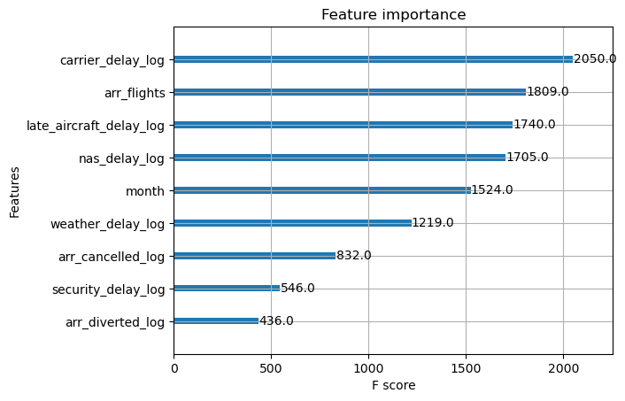

```python
from xgboost import plot_importance
plot_importance(xgb_model_tuned)
plt.show()
```

### Model 6: Feedforward Neural Network (FNN)

#### Methods

- Fully Connected Neural Network (FNN):
  - A sequence of densely connected layers where each neuron in a layer connects to every neuron in the next layer.
  - Uses ReLU activation for hidden layers to model non-linear relationships and linear activation for the output layer, suited for regression tasks.
- Backpropagation and Gradient Descent: The model is trained using backpropagation to minimize the Mean Squared Error (MSE), optimizing weights via the Adam optimizer.
- Batch Learning: Data is processed in batches of 32 samples, and the model iteratively learns from these batches over 50 epochs.

#### Strengths

- Flexibility in Capturing Non-Linear Relationships: Can model complex, non-linear relationships between numerical time-based predictors and total delay.
- Scalability: Capable of scaling to large datasets with sufficient computational resources.
- Parallelized Computation: Uses GPU acceleration (if available), making training efficient for moderately sized datasets.
- Customizability: The architecture (e.g., number of layers, neurons, activation functions) can be tailored to suit the specific problem.
- Continuous Improvement: Additional hidden layers or advanced architectures can enhance the model's predictive power.

#### Limitations

- Black Box Nature: Harder to interpret compared to simpler models like Linear Regression or Decision Trees.
- Risk of Overfitting: Requires careful tuning (e.g., dropout layers, regularization) to avoid overfitting when the dataset is small or noisy.
- Computational Cost: Neural networks can be computationally expensive, especially for deeper architectures.
- Dependence on Feature Scaling: Requires proper scaling of input features for effective training (e.g., using StandardScaler).

#### Results

```python
from tensorflow.keras.models import Sequential
from tensorflow.keras.layers import Dense

# Define the FNN model
model_nn = Sequential([
    Dense(64, input_dim=X_train.shape[1], activation='relu'),  # First hidden layer
    Dense(32, activation='relu'),                              # Second hidden layer
    Dense(1, activation='linear')                              # Output layer for regression
])

# Compile the model
model_nn.compile(optimizer='adam', loss='mse', metrics=['mae'])
model_nn.fit(X_train, y_train, validation_data=(X_test, y_test), epochs=50, batch_size=32, verbose=0)

mse_nn, mae_nn = model_nn.evaluate(X_test, y_test, verbose=1)
rmse_nn = np.sqrt(mse_nn)
y_pred_nn = model_nn.predict(X_test)
r2_nn = r2_score(y_test, y_pred_nn)

print("Mean Squared Error:", mse_nn)
print("Root Mean Squared Error:", rmse_nn)
print("Mean Absolute Error:", mae_nn)
print("R² Score:", r2_nn)
```

```
9/9 ━━━━━━━━━━━━━━━━━━━━ 0s 1ms/step - loss: 0.2808 - mae: 0.3948
9/9 ━━━━━━━━━━━━━━━━━━━━ 0s 2ms/step
Mean Squared Error: 0.27115729451179504
Root Mean Squared Error: 0.5207276586775423
Mean Absolute Error: 0.39337030053138733
R² Score: 0.8758213929957908
```

### Hyperparameter Tuning

#### Strategy and Outcome

```python
import keras_tuner as kt
import tensorflow as tf

# Define the hypermodel function
def build_model(hp):
    model = Sequential([
        Dense(hp.Choice('neurons', [32, 64, 128]), activation='relu', input_dim=X_train.shape[1]),
        Dense(hp.Int('neurons_hidden', min_value=16, max_value=64, step=16), activation='relu'),
        Dense(1, activation='linear')
    ])
    model.compile(
        optimizer=tf.keras.optimizers.Adam(
            learning_rate=hp.Choice('learning_rate', [0.01, 0.001, 0.0001])
        ),
        loss='mse',
        metrics=['mae']
    )
    return model

# Initialize the tuner
tuner = kt.RandomSearch(
    build_model,
    objective='val_loss',
    max_trials=10,  # Number of hyperparameter combinations to try
    directory='tuning_dir',
    project_name='fnn_tuning'
)

# Search for the best hyperparameters
tuner.search(X_train, y_train, validation_data=(X_test, y_test), epochs=50, batch_size=32, verbose=0)

# Get the best hyperparameters
best_hps = tuner.get_best_hyperparameters(1)[0]
print("Best Hyperparameters:", best_hps.values)

# Train the best model
nn_model_tuned = tuner.hypermodel.build(best_hps)
nn_model_tuned.fit(X_train, y_train, validation_data=(X_test, y_test), epochs=50, batch_size=32, verbose=0)
```

```
Best Hyperparameters: {'neurons': 128, 'neurons_hidden': 64, 'learning_rate': 0.01}
```

```
<keras.src.callbacks.history.History at 0x333884c50>
```

#### Conclusion:

```python
mse_nn_tuned, mae_nn_tuned = nn_model_tuned.evaluate(X_test, y_test, verbose=1)
rmse_nn_tuned = np.sqrt(mse_nn_tuned)
y_pred_nn_tuned = nn_model_tuned.predict(X_test)
r2_nn_tuned = r2_score(y_test, y_pred_nn_tuned)

print("Mean Squared Error:", mse_nn_tuned)
print("Root Mean Squared Error:", rmse_nn_tuned)
print("Mean Absolute Error:", mae_nn_tuned)
print("R² Score:", r2_nn_tuned)
```

```
9/9 ━━━━━━━━━━━━━━━━━━━━ 0s 1ms/step - loss: 0.2036 - mae: 0.2928
9/9 ━━━━━━━━━━━━━━━━━━━━ 0s 3ms/step
Mean Squared Error: 0.1928008496761322
Root Mean Squared Error: 0.43909093554311984
Mean Absolute Error: 0.2833355963230133
R² Score: 0.9117053358230127
```

## Supervised Learning Model Comparisons

While SVR provides the best performance, Random Forest and XGBoost are strong alternatives.

#### Best Overall Model: SVR

- With the lowest MSE, RMSE, and MAE, and the highest R² score, the SVR model outperforms all others.
- Excellent balance of low errors and high explanatory power.
- Strong Performance: Random Forest and XGBoost

#### XGBRegressor

- Performs slightly worse than Random Forest but still provides strong results with low errors and a high R² score.

#### Linear Regression and Decision Tree:

- While these models perform reasonably well, they are outclassed by the ensemble models and SVR.
  - Linear Regression: A simpler model with good interpretability but higher errors and lower R² score.
  - Decision Tree: Slightly worse performance due to its tendency to overfit without ensembles.

#### FeedForward Neural Net:

- This model performs the worst of all the models accross all methods of evaulation.

```python
results = {
    "Model": ["Linear Regression", "Decision Tree", "Random Forest", "SVR", "XGBoost", "FNN"],
    "MSE": [mse_linreg, mse_dt_tuned, mse_rf_tuned, mse_svr_tuned, mse_xgb_tuned, mse_nn_tuned],
    "RMSE": [rmse_linreg, rmse_dt_tuned, rmse_rf_tuned, rmse_svr_tuned, rmse_xgb_tuned, rmse_nn_tuned],
    "MAE": [mae_linreg, mae_dt_tuned, mae_rf_tuned, mae_svr_tuned, mae_xgb_tuned, mae_nn_tuned],
    "R²": [r2_linreg, r2_dt_tuned, r2_rf_tuned, r2_svr_tuned, r2_xgb_tuned, r2_nn_tuned]
    }

results_df = pd.DataFrame(results)
print(results_df)
```

```
               Model       MSE      RMSE       MAE        R²
0  Linear Regression  0.075037  0.273928  0.155118  0.965636
1      Decision Tree  0.082069  0.286478  0.205617  0.962416
2      Random Forest  0.016639  0.128991  0.073853  0.992380
3                SVR  0.002620  0.051190  0.026256  0.998800
4            XGBoost  0.025115  0.158477  0.062991  0.988498
5                FNN  0.192801  0.439091  0.283336  0.911705
```

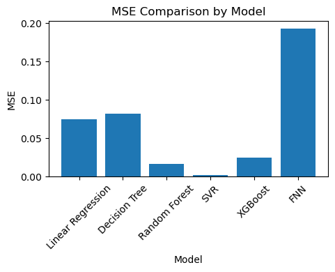

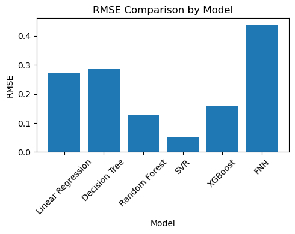

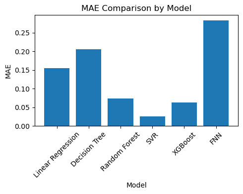

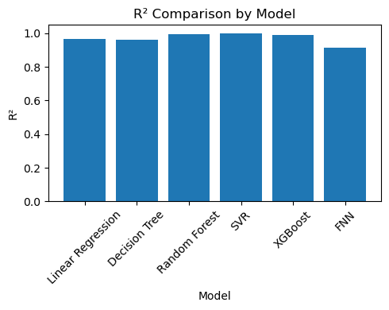

```python
metrics = ["MSE", "RMSE", "MAE", "R²"]
for metric in metrics:
    plt.figure(figsize=(5, 4))  # Create a new figure for each plot
    plt.bar(results_df["Model"], results_df[metric], color=myblue)
    plt.title(f"{metric} Comparison by Model")
    plt.ylabel(metric)
    plt.xlabel("Model")
    plt.xticks(rotation=45)  # Rotate x-axis labels for better readability
    plt.tight_layout()  # Adjust layout to prevent overlap
    plt.show()
```

```python
import time

start_linreg = time.time()
linreg.fit(X_train, y_train)
end_linreg = time.time()
total_linreg = end_linreg - start_linreg

start_dt_tuned = time.time()
dt_model_tuned.fit(X_train, y_train)
end_dt_tuned = time.time()
total_dt_tuned = end_dt_tuned - start_dt_tuned

start_rf_tuned = time.time()
rf_model_tuned.fit(X_train, y_train)
end_rf_tuned = time.time()
total_rf_tuned = end_rf_tuned - start_rf_tuned

start_svr_tuned = time.time()
svr_model_tuned.fit(X_train, y_train)
end_svr_tuned = time.time()
total_svr_tuned = end_svr_tuned - start_svr_tuned

start_xgb_tuned = time.time()
xgb_model_tuned.fit(X_train, y_train)
end_xgb_tuned = time.time()
total_xgb_tuned = end_xgb_tuned - start_xgb_tuned

start_nn_tuned = time.time()
nn_model_tuned.fit(X_train, y_train)
end_nn_tuned = time.time()
total_nn_tuned = end_nn_tuned - start_nn_tuned
```

```
35/35 ━━━━━━━━━━━━━━━━━━━━ 0s 1ms/step - loss: 0.1374 - mae: 0.2496
```

#### Computation Time:

While this dataset is relatively small, larger datasets may be very computationally expensive. The time it takes to compile may be important, especially since all models had realtively low error and high R² scores.

Moderately Fast:

- Support Vector Regression (SVR): Computationally more expensive due to the kernel transformations and optimization processes, but still reasonably fast at under 0.1 seconds.

More Time-Consuming:

- XGBRegressor: Slower due to its iterative boosting process, which builds multiple trees sequentially and optimizes at each step.
- Random Forest: Slower, as it builds a large number of decision trees independently (500 in your case), requiring significant computation.
- FeedForward Neural Net: Slower as it requires multiple forward and backward passes during training, which increases computational complexity.

```python
time_data = {
    'Model': ['Linear Regression', 'Decision Tree', 'Random Forest Regression', 'Support Vector Regression', 'XGBRegressor', 'FeedForward Neural Net'],
    'Time (s)': [total_linreg, total_dt_tuned, total_rf_tuned, total_svr_tuned, total_xgb_tuned, total_nn_tuned]
}

time_df = pd.DataFrame(time_data)
sorted_time_df = time_df.sort_values(by='Time (s)')
print(sorted_time_df)
```

```
                       Model  Time (s)
1              Decision Tree  0.007513
0          Linear Regression  0.044250
3  Support Vector Regression  0.065484
5     FeedForward Neural Net  0.090559
4               XGBRegressor  0.263912
2   Random Forest Regression  1.294899
```

### Comparison of Residuals

The residuals for all models appear to be relatively close to 0, with a few points being significanatly different. This is a good indicator that the models are generalizing well.

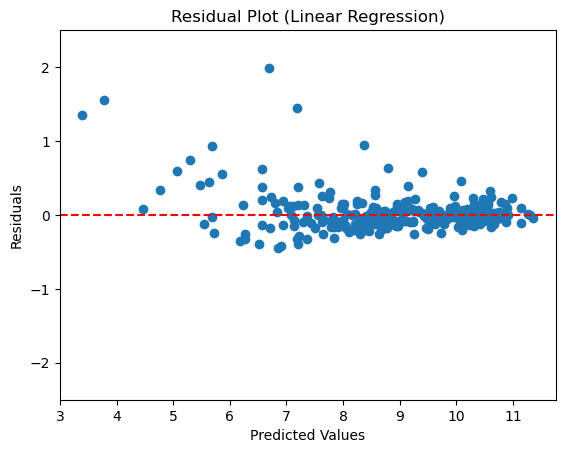

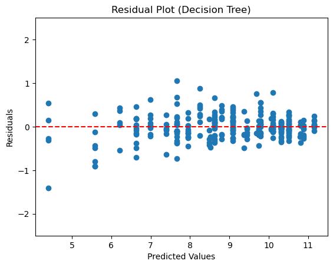

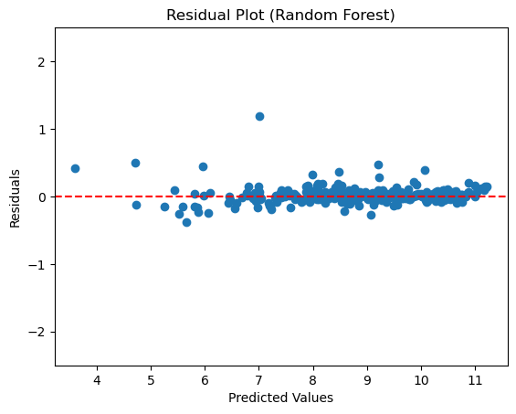

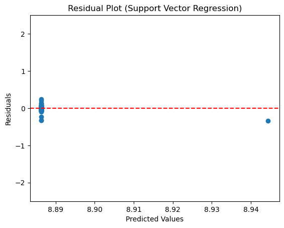

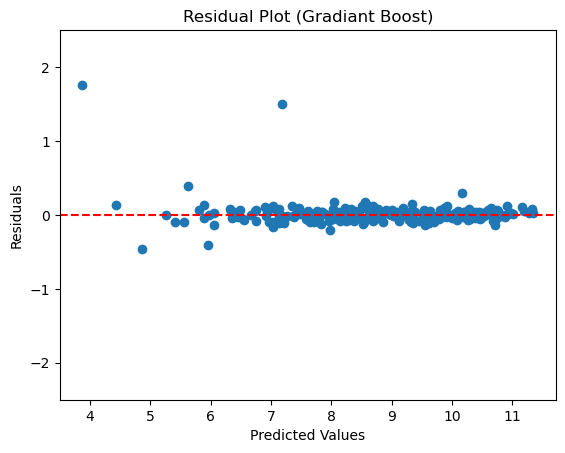

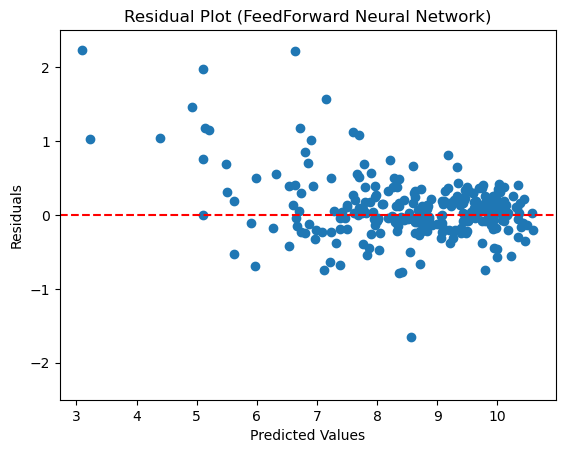

```python
import matplotlib.pyplot as plt

residuals = y_test - y_pred_linreg
plt.scatter(y_pred_linreg, residuals)
plt.axhline(y=0, color='r', linestyle='--')
plt.xlabel("Predicted Values")
plt.ylabel("Residuals")
plt.title("Residual Plot (Linear Regression)")
plt.ylim(-2.5, 2.5)
plt.show()

residuals = y_test - y_pred_dt_tuned
plt.scatter(y_pred_dt, residuals)
plt.axhline(y=0, color='r', linestyle='--')
plt.xlabel("Predicted Values")
plt.ylabel("Residuals")
plt.title("Residual Plot (Decision Tree)")
plt.ylim(-2.5, 2.5)
plt.show()

residuals = y_test - y_pred_rf_tuned
plt.scatter(y_pred_rf, residuals)
plt.axhline(y=0, color='r', linestyle='--')
plt.xlabel("Predicted Values")
plt.ylabel("Residuals")
plt.title("Residual Plot (Random Forest)")
plt.ylim(-2.5, 2.5)
plt.show()

residuals = y_test - y_pred_svr_tuned
plt.scatter(y_pred_svr, residuals)
plt.axhline(y=0, color='r', linestyle='--')
plt.xlabel("Predicted Values")
plt.ylabel("Residuals")
plt.title("Residual Plot (Support Vector Regression)")
plt.ylim(-2.5, 2.5)
plt.show()

residuals = y_test - y_pred_xgb_tuned
plt.scatter(y_pred_xgb, residuals)
plt.axhline(y=0, color='r', linestyle='--')
plt.xlabel("Predicted Values")
plt.ylabel("Residuals")
plt.title("Residual Plot (Gradiant Boost)")
plt.ylim(-2.5, 2.5)
plt.show()

y_pred_nn_tuned = y_pred_nn_tuned.flatten()
residuals = y_test - y_pred_nn_tuned
plt.scatter(y_pred_nn, residuals)
plt.axhline(y=0, color='r', linestyle='--')
plt.xlabel("Predicted Values")
plt.ylabel("Residuals")
plt.title("Residual Plot (FeedForward Neural Network)")
plt.ylim(-2.5, 2.5)
plt.show()
```

### Conclusion

All models performed well and were efficient at predicting total delays. The Support Vector Regression model was the best overall, giving the best accuracy, lowest error metrics, and a moderate computation time.

- If prediction speed is the priority: Linear Regression or Decision Tree.
- If accuracy is the priority: SVR or Random Forest.

Finding the best model is important because it can help airlines figure out what is causing delays and allow them to make changes in order to prevent flights from being delayed so often.